# Attitudes toward Redistribution Thirty Years After: Theoretical and Empirical Reflections on Svallfors’ (1997) Findings

### Table 2. A Weighted version of Svallfors’ Table 1

This table uses the dplyr::mutate function to obtain weighted means then tabulates.

```r
socIn92recode<-socIn92recode %>%
  group_by(v3)%>%
  dplyr::mutate(
    wmean_r1p = weighted.mean(r1p,v176),
    wmean_r2p = weighted.mean(r2p,v176),
    wmean_r3p = weighted.mean(r3p,v176))

govinc_w<-tapply(socIn92recode$wmean_r1p,socIn92recode$v3,mean)
govjobs_w<-tapply(socIn92recode$wmean_r2p,socIn92recode$v3,mean)
govbas_w<-tapply(socIn92recode$wmean_r3p,socIn92recode$v3,mean)

table1_w<-as.data.frame(rbind(govinc_w,govjobs_w,govbas_w))
table1_w<-table1_w[,c(6,5,2,4,1,7,8,3)]

row.names(table1_w)<-item.table1
colnames(table1_w) = cnt

t2 <- knitr::kable(table1_w,format="html", digits = round(1), caption = "Table 2. Weighted Version of Table 1")

column_spec(t2, 2:9, "4em")
```

Table 2. Weighted Version of Table 1

|  | Swe | Nor | Ger | Aut | Aus | NZ | Can | USA |
| --- | --- | --- | --- | --- | --- | --- | --- | --- |
| It is the responsibility of the government to reduce the differences between people with high incomes and those with low incomes? | 53.2 | 60.6 | 65.2 | 69.8 | 42.5 | 53.1 | 47.8 | 39.2 |
| The government should provide a job for everyone who wants one? | 73.2 | 78.9 | 65.4 | 72.3 | 39.2 | 49.3 | 40.9 | 47.3 |
| The government should provide everyone with a guaranteed basic income? | 44.7 | 78.4 | 57.9 | 50.3 | 50.7 | 60.6 | 49.5 | 35.0 |

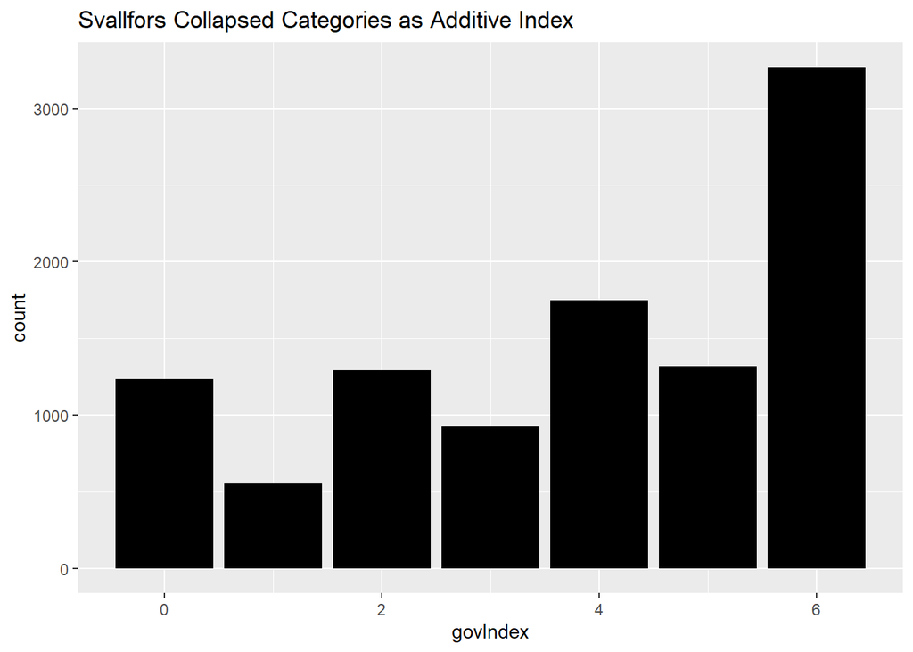

```r
ggplot(socIn92recode, aes(govIndex)) +
  geom_bar(fill = "black") +
  ggtitle("Svallfors Collapsed Categories as Additive Index")
```

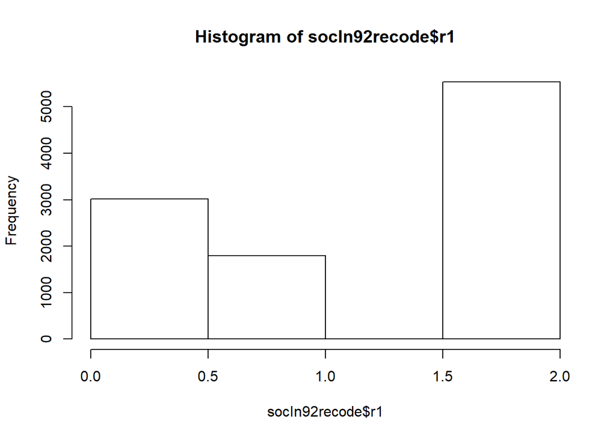

```r
hist(socIn92recode$r1, 3)
```

### Table 3. Replication of Svallfors “Table 2”

Here we replicate **Tabel 2: Index distribution** in the same way we constructed Table 1.

```r
#mean and standard deviation
govIndexmean<-tapply(socIn92recode$govIndex,socIn92recode$v3,mean)
govIndexsd<-tapply(socIn92recode$govIndex,socIn92recode$v3,sd)

#cronbach's alpha by country (here for the recoded variable r1,r2,r3 = 394:396!)
a <- list(1,2,5,6,9,10,16,17)
cronalpha <- round(unlist(as.data.frame(sapply(a, function(x) {
  c <-socIn92recode[which(socIn92recode$v3 == x),c(394:396)]
  cronbach.alpha(c)
}))[1,]),2)
table2[3,] <- cronalpha

table2<-as.data.frame(rbind(govIndexmean,govIndexsd,cronalpha))
table2<-table2[,c(6,5,2,4,1,7,8,3)]

item.table2<-c("Mean","Standard Deviation", "Cronbach's alpha")
row.names(table2)<- item.table2
colnames(table2)<- cnt


t3 <- knitr::kable(table2,format="html", digits = round(2), caption = "Table 3. Government Index Descriptives and Alpha (replication of \"Table 2\" in Svallfors (1997)")

column_spec(t3, 2:9, "4em")
```

Table 3. Government Index Descriptives and Alpha (replication of “Table 2” in Svallfors (1997)

|  | Swe | Nor | Ger | Aut | Aus | NZ | Can | USA |
| --- | --- | --- | --- | --- | --- | --- | --- | --- |
| Mean | 3.93 | 4.72 | 4.21 | 4.29 | 3.26 | 3.73 | 3.24 | 2.86 |
| Standard Deviation | 1.85 | 1.66 | 1.96 | 1.71 | 2.10 | 2.01 | 2.18 | 2.29 |
| Cronbach’s alpha | 0.64 | 0.64 | 0.70 | 0.52 | 0.70 | 0.63 | 0.73 | 0.79 |

### Table 4. Descrepancies in our results

From the start of this project we noticed small differences in the descriptive statistics between the original Svallfors study and ours. We suspect this is due to our usage of the GESIS 1992 ISSP data versus Svallfors’ 1992 data file which was not cleaned, standardized and archived. **We plan to contact Svallfors when our work is closer to completion to ask about these descrepancies.**

Table 4 demonstrates the differences between our results and Svallfors’ results. Panel A has unweighted and Panel B weighted differences in means.

```r
#Now we want to compare our results for table 1 with the results of Svallfors

#Here we create a copy of table 1 with the original values of Svallfors

table1Sval<-data.frame(matrix(c(53.7,74.1,45.5,60.0,78.3,78.4,65.5,66.3, 58.1,69.5,72.1,51.2, 42.6, 39.4, 50.9, 53.1, 49.1, 60.5, 47.9, 40.1, 48.6, 38.3, 47.1, 34.2),nrow = 3,ncol = 8))
row.names(table1Sval)<-item.table1
colnames(table1Sval) = cnt

#The deviations of our replicated table and the original table in Svallfors' article.
table1diff <- round(table1 - table1Sval,2)

#Here our weighted table versus his original table.
table1diff_w <- round(table1_w - table1Sval,2)
```

```r
# Code to produce the two tables

t4a <- knitr::kable(table1diff, format="html", digits = round(3), caption = "Panel A. Unweighted Discrepancies")

column_spec(t4a, 2:9, "4em")

t4b <- knitr::kable(table1diff_w, format="html", digits = round(3), caption = "Panel B. Weighted Discrepancies")

column_spec(t4b, 2:9, "4em")
```

Table 4. Descrepancies in Author Results versus Svallfors’ (1997) Original.

Panel A. Unweighted Discrepancies

|  | Swe | Nor | Ger | Aut | Aus | NZ | Can | USA |
| --- | --- | --- | --- | --- | --- | --- | --- | --- |
| It is the responsibility of the government to reduce the differences between people with high incomes and those with low incomes? | -1.45 | 0.04 | -0.28 | -0.22 | -0.14 | -0.05 | -0.34 | -0.01 |
| The government should provide a job for everyone who wants one? | -2.78 | 0.09 | -0.93 | 0.01 | -0.16 | 0.20 | -0.29 | -0.67 |
| The government should provide everyone with a guaranteed basic income? | -3.01 | -0.15 | -0.22 | -0.11 | -0.24 | 0.06 | -0.19 | -0.07 |

Panel B. Weighted Discrepancies

|  | Swe | Nor | Ger | Aut | Aus | NZ | Can | USA |
| --- | --- | --- | --- | --- | --- | --- | --- | --- |
| It is the responsibility of the government to reduce the differences between people with high incomes and those with low incomes? | -0.49 | 0.60 | -0.28 | 0.29 | -0.14 | -0.05 | -0.06 | 0.93 |
| The government should provide a job for everyone who wants one? | -0.89 | 0.55 | -0.93 | 0.16 | -0.16 | 0.20 | 0.84 | 0.22 |
| The government should provide everyone with a guaranteed basic income? | -0.81 | 0.04 | -0.22 | -0.93 | -0.24 | 0.06 | 0.90 | 0.81 |

### Class Scheme Coding

We attempt to replicate the Erikson, Goldthorpe and Portracrero [1979](https://www.jstor.org/stable/589632) Class Scheme. From Svallfors’ article he claims to followtheir coding scheme. We follow the EGP to the best of our ability by recoding various occupational codes provided by the countries in 1992; in other words, not all provided ISCO back then. Our resulting EGP scheme follows but does not exactly replicate Svallfors’ results. We are unsure if this is a result of the data being slight different (see Tables 1-4) or if Svallfors’ class coding scheme was different.

Svallfors provides his original SPSS coding to construct his class schemes. **We will replicate this coding at some point.**

```r
#here we replicate the class scheme

#we thought we could get the scheme from the cumulative ISSP

socIncum <- read_dta(paste(wd, "ZA5890_v1-0-0.dta", sep = ""))
socIn92new <- socIncum[which(socIncum$V5 %in% c(752, 578, 276, 40, 36, 554, 124, 840) & socIncum$V4 == 1992),]
socIn92new <- socIn92new[,c("V3","ISCO88")]

#but there are no ISCO88 codes for 1992 so we are stuck with the Swedish coding
#It uses NYK 'Nordic Occupational Classification System

socIn92new <- dplyr::rename(socIn92new, v2 = V3)

newdata <- as.data.frame(left_join(socIn92recode, socIn92new, by = "v2"))

newdata$v110 <- car::recode(newdata$v110, recodes = '2=0')

#Here is the NYK scheme for Sweden (variable s106)
#It appears that Svallfors' original data was SEI classification (2-digit), but that provided in the ISSP from GESIS is NYK83
#we use Erik Bihagen's translation of NYK into ISCO88 [although they are not perfectly transferrable!!] http://www.camsis.stir.ac.uk/occunits/SwedishNYK8590majgpsv1.sps

newdata$isco88se <- car::recode(newdata$s106, recodes = "
1 = 2141; 2 = 2143; 3 = 2144; 4 = 2145; 5 = 3116; 6 = 3117; 7 = 2142; 8 = 2148; 9 = 3119; 12 = 3211; 13 = 3211; 14 = 2114; 15 = 2112; 16 = 2113; 19 = 3111; 21 = 2211; 22 = 3213; 23 = 3213; 29 = 2211; 30 = 1210; 31 = 2310; 32 = 2320; 33 = 2331; 34 = 2320; 35 = 2359; 36 = 2320; 37 = 2352; 39 = 2359; 41 = 2460; 49 = 3480; 51 = 2421; 52 = 2429; 53 = 2429;
54 = 2429; 59 = 2429; 61 = 2451; 62 = 1234; 63 = 1229; 69 = 2451; 71 = 2452; 72 = 3471; 73 = 3471; 74 = 3131; 75 = 3474; 76 = 2453; 77 = 2455; 79 = 2455; 91 = 2432; 92 = 2431; 99 = 2446; 101 = 2221; 102 = 2230; 103 = 3231; 104 = 3232; 105 = 3133; 106 = 5132; 107 = 5132; 109 = 9132; 111 = 3226; 112 = 2229; 119 = 3226; 121 = 2222; 122 = 3225; 123 = 3225; 129 = 3225; 131 = 2224; 139 = 3228; 141 = 2223; 149 = 3227; 151 = 2446; 152 = 1228; 153 = 5131; 154 = 5133; 155 = 1228; 159 = 2446; 161 = 3152; 162 = 3151; 169 = 3152; 191 = 2445; 192 = 3223; 199 = 3460; 201 = 1110; 202 = 3443; 203 = 3444; 209 = 1110; 211 = 2419; 212 = 3431; 219 = 2419; 221 = 2412; 222 = 3423; 229 = 2412; 231 = 2411; 232 = 2411; 239 = 4121; 241 = 4115; 242 = 4111; 249 = 4190; 251 = 2131; 252 = 3122; 259 = 3121; 261 = 2441; 262 = 2122; 269 = 2441; 291 = 4190; 292 = 4122; 293 = 3412; 294 = 3412; 295 = 4221; 296 = 3422; 297 = 1317; 299 = 4190; 311 = 3471; 312 = 3413; 313 = 3419; 319 = 3419; 321 = 3416; 331 = 1314; 332 = 5220; 333 = 5220; 339 = 5220; 399 = 5220; 400 = 1311; 401 = 6112; 402 = 6130; 403 = 6130; 404 = 6130; 405 = 6130; 406 = 6129; 409 = 6112; 411 = 6112; 412 = 6121; 413 = 6112; 414 = 6129; 419 = 6121; 421 = 6154; 431 = 6152; 432 = 6151; 439 = 6152; 441 = 6141; 449 = 6141; 501 = 7111; 509 = 7111; 511 = 8113; 521 = 8121; 531 = 8155; 599 = 7111; 601 = 3142; 602 = 3142; 603 = 3141; 609 = 3142; 611 = 8340; 612 = 8340; 619 = 8340; 621 = 3143; 629 = 3143; 631 = 8311; 640 = 8322; 641 = 8324; 642 = 8322; 643 = 9151; 649 = 8334; 651 = 3144; 652 = 5112; 653 = 5111; 659 = 5112; 661 = 4133; 662 = 3144; 663 = 8312; 664 = 4133; 669 = 4133; 671 = 4142; 673 = 3132; 674 = 3132; 675 = 3132; 679 = 4142; 681 = 4142; 682 = 9151; 689 = 4142; 691 = 4133; 699 = 9330; 701 = 8261; 702 = 7332; 703 = 7432; 705 = 8262; 706 = 7435; 707 = 3152; 709 = 7332; 711 = 7433; 712 = 7434; 713 = 7433; 714 = 7437; 715 = 7435; 716 = 7433; 719 = 7436; 721 = 7442; 722 = 7442; 723 = 8268; 729 = 8269; 731 = 8121; 732 = 8122; 733 = 8122; 735 = 7215; 736 = 7221; 737 = 7211; 739 = 8122; 741 = 7311; 742 = 7311; 743 = 3224; 744 = 3211; 745 = 7313; 746 = 7323; 749 = 7222; 751 = 8211; 752 = 7233; 753 = 7231; 754 = 7213; 755 = 7136; 756 = 7212; 757 = 7214; 758 = 8223; 759 = 7214; 761 = 7241; 762 = 7241; 763 = 8282; 764 = 7244; 765 = 7245; 766 = 3131; 769 = 8282; 771 = 6141; 772 = 8141; 773 = 8240; 775 = 7331; 776 = 7331; 777 = 7423; 779 = 8141; 781 = 7141; 782 = 7132; 783 = 7141; 789 = 7139; 791 = 7122; 793 = 7123; 794 = 7124; 795 = 7134; 796 = 7135; 799 = 7129; 801 = 7341; 802 = 7343; 803 = 8251; 804 = 7345; 805 = 8224; 809 = 8251; 811 = 7322; 812 = 7321; 813 = 8131; 814 = 7323; 819 = 8139; 821 = 8273; 822 = 7412; 823 = 8274; 824 = 8278; 825 = 9320; 826 = 7411; 827 = 8272; 828 = 8279; 829 = 8278; 831 = 8159; 832 = 8151; 833 = 8151; 834 = 8231; 835 = 8232; 839 = 8159; 841 = 8142; 842 = 8143; 843 = 8253; 849 = 8142; 851 = 7129; 852 = 8265; 853 = 7312; 854 = 7113; 859 = 7222; 861 = 8161; 869 = 8161; 871 = 8333; 872 = 8332; 873 = 8334; 879 = 9330; 881 = 9320; 882 = 9330; 889 = 9320; 891 = 9151; 901 = 5161; 902 = 9162; 903 = 5162; 904 = 3441; 905 = 5163; 906 = 5169; 909 = 5169; 911 = 1225; 912 = 5122; 913 = 5123; 914 = 5123; 915 = 4222; 916 = 5111; 919 = 5123; 921 = 5121; 929 = 5121; 931 = 9141; 932 = 9131; 939 = 9141; 941 = 5141; 942 = 5149; 949 = 5141; 951 = 9133; 952 = 9133; 959 = 9133; 961 = 3475; 971 = 5143; 979 = 5149; 981 = 110; 989 = 110")

#now merge the imputed SE ISCO
newdata$ISCO88 <- ifelse(newdata$v3==10,newdata$isco88se,newdata$ISCO88)

newdata$egp <- occupar::isco88toEGP(newdata$ISCO88, self.employed = newdata$v110, n.employees = newdata$v108)

newdata <- newdata %>%
  mutate(
    egp6 = car::recode(egp, recodes = '"I     Service class I" = "Service I";"II    Service class II" = "Service II"; "III.a Routine non-manual, higher grade" = "Routine"; "III.b Routine non-manual, lower grade" = "Routine"; "IV.a  Self-employed with employees" = "Self"; "IV.b  Self-employed with no empoyees" = "Self"; "IV.c  Self-employed Farmers etc" = "Self"; "V     Manual supervisors/Lower grade technicians" = "Skilled";"VI    Skilled workers" = "Skilled"; "VII.a Unskilled workers" = "Unskilled"; "VII.b Farm labours" = "Unskilled"')
  ) #V Manual supervisors = Skilled in Svallfors' coding. It's another decision he made.
```

### Table 5. Distribution of Government Index by EGP Class and Country

```r
tableA2 <- round(as.data.frame(sapply(list(10,9,2,6,1,16,17,5), function(x) {
  d <<- newdata[which(newdata$v3 == x),]
  tapply(d$govIndex,d$egp6, mean)
  })),2)
colnames(tableA2) <- c("Swe","Nor","Ger","Aut","Aus","NZ","Can","USA")
t5 <- knitr::kable(tableA2,format="html", digits = round(2), caption = "Distribution of \'Government Index\' by EGP Class and Country. Part of Svallfors\' \"Table A2\"")

column_spec(t5, 2:9, "4em")
```

Distribution of ‘Government Index’ by EGP Class and Country. Part of Svallfors’ “Table A2”

|  | Swe | Nor | Ger | Aut | Aus | NZ | Can | USA |
| --- | --- | --- | --- | --- | --- | --- | --- | --- |
| Routine | 4.07 | 5.02 | 4.29 | 4.16 | 3.26 | 3.70 | 3.54 | 3.00 |
| Self | 3.21 | 4.25 | 3.54 | 3.94 | 2.60 | 2.84 | 2.98 | 2.10 |
| Service I | 3.12 | 3.65 | 2.98 | 3.90 | 2.55 | 2.67 | 2.47 | 2.03 |
| Service II | 3.47 | 4.44 | 4.02 | 3.43 | 3.08 | 3.54 | 3.46 | 2.40 |
| Skilled | 4.56 | 5.10 | 4.60 | 4.60 | 3.72 | 4.39 | 3.45 | 3.59 |
| Unskilled | 4.40 | 5.24 | 4.86 | 5.43 | 3.29 | 3.50 | 6.00 | 2.88 |

```r
newdata$female<-car::recode(newdata$v99, recodes = '1=0; 2=1')
newdata$empl<-car::recode(newdata$v104, recodes = '1:3=0; 5=1; c(4,6,8,9,10)=3; 7=2')

newdata$unskilled<-car::recode(newdata$egp6, recodes = '"Service I"=4; "Service II"=3; "Routine"=2; "Self"=5; "Skilled"=1;"Unskilled"=0')

m1nor<- lm(govIndex~female+factor(unskilled)+factor(empl),data = newdata, subset = (v3 %in% c(9)))

m1ger<- lm(govIndex~female+factor(unskilled)+factor(empl),data = newdata, subset = (v3 %in% c(2)))

m1aus<- lm(govIndex~female+factor(unskilled)+factor(empl),data = newdata, subset = (v3 %in% c(1)))

m1usa<- lm(govIndex~female+factor(unskilled)+factor(empl),data = newdata, subset = (v3 %in% c(5)))


table4<- stargazer(m1nor, m1ger, m1aus, m1usa, title= "Table 4",type = "text", single.row = TRUE, report = "vc*", star.cutoffs = c(0.05,0.01,0.001), covariate.labels = c("Female", "Skilled", "Routine non-manual", "Service class II", "Service class I", "Self-employed", "Unemployed", "Retired", "Others not in labor force"), column.labels = c("Norway", "Germany", "Australia", "USA"))
```

```
##
## Table 4
## ============================================================================================================================
##                                                                  Dependent variable:
##                           --------------------------------------------------------------------------------------------------
##                                                                        govIndex
##                                    Norway                  Germany                 Australia                  USA
##                                     (1)                      (2)                      (3)                     (4)
## ----------------------------------------------------------------------------------------------------------------------------
## Female                            0.606***                 0.515***                 0.312**                 0.599***
## Skilled                            -0.242                   -0.116                   0.480                   0.553
## Routine non-manual                 -0.500                  -0.655*                  -0.128                   -0.255
## Service class II                 -0.958***                 -0.804*                  -0.210                   -0.756
## Service class I                  -1.543***                -1.576***                 -0.645                   -0.966
## Self-employed                     -1.001**                 -1.057**                 -0.594                   -0.833
## Unemployed                        0.798***                  0.631*                   0.066                   0.403
## Retired                            0.256                    0.005                    0.073                   -0.318
## Others not in labor force          0.030                    0.197                    0.146                   0.133
## Constant                          4.984***                 4.481***                3.098***                 2.756***
## ----------------------------------------------------------------------------------------------------------------------------
## Observations                       1,225                    1,511                    1,607                   1,085
## R2                                 0.123                    0.078                    0.042                   0.090
## Adjusted R2                        0.117                    0.073                    0.036                   0.083
## Residual Std. Error          1.590 (df = 1215)        1.890 (df = 1501)        2.061 (df = 1597)       2.191 (df = 1075)
## F Statistic               19.015*** (df = 9; 1215) 14.128*** (df = 9; 1501) 7.746*** (df = 9; 1597) 11.834*** (df = 9; 1075)
## ============================================================================================================================
## Note:                                                                                          *p<0.05; **p<0.01; ***p<0.001
```

```r
#to make it a file

table4 %>% paste(., collapse="\n") %>% cat("\n")
```

```
##
## Table 4
## ============================================================================================================================
##                                                                  Dependent variable:
##                           --------------------------------------------------------------------------------------------------
##                                                                        govIndex
##                                    Norway                  Germany                 Australia                  USA
##                                     (1)                      (2)                      (3)                     (4)
## ----------------------------------------------------------------------------------------------------------------------------
## Female                            0.606***                 0.515***                 0.312**                 0.599***
## Skilled                            -0.242                   -0.116                   0.480                   0.553
## Routine non-manual                 -0.500                  -0.655*                  -0.128                   -0.255
## Service class II                 -0.958***                 -0.804*                  -0.210                   -0.756
## Service class I                  -1.543***                -1.576***                 -0.645                   -0.966
## Self-employed                     -1.001**                 -1.057**                 -0.594                   -0.833
## Unemployed                        0.798***                  0.631*                   0.066                   0.403
## Retired                            0.256                    0.005                    0.073                   -0.318
## Others not in labor force          0.030                    0.197                    0.146                   0.133
## Constant                          4.984***                 4.481***                3.098***                 2.756***
## ----------------------------------------------------------------------------------------------------------------------------
## Observations                       1,225                    1,511                    1,607                   1,085
## R2                                 0.123                    0.078                    0.042                   0.090
## Adjusted R2                        0.117                    0.073                    0.036                   0.083
## Residual Std. Error          1.590 (df = 1215)        1.890 (df = 1501)        2.061 (df = 1597)       2.191 (df = 1075)
## F Statistic               19.015*** (df = 9; 1215) 14.128*** (df = 9; 1501) 7.746*** (df = 9; 1597) 11.834*** (df = 9; 1075)
## ============================================================================================================================
## Note:                                                                                          *p<0.05; **p<0.01; ***p<0.001
```

```r
newdata2<- subset(newdata,v3==5)

gmean<-tapply(newdata2$govIndex,newdata2$egp,mean)
gsd<-tapply(newdata2$govIndex,newdata2$egp,sd)
table6<-as.data.frame(rbind(gmean,gsd))

knitr::kable(table6,format="html", digits = round(2), caption = "Exploring the Standard Deviations to Understand Discrepancies")
```

Exploring the Standard Deviations to Understand Discrepancies

|  | I Service class I | II Service class II | III.a Routine non-manual, higher grade | III.b Routine non-manual, lower grade | IV.a Self-employed with employees | IV.b Self-employed with no empoyees | IV.c Self-employed Farmers etc | V Manual supervisors/Lower grade technicians | VI Skilled workers | VII.a Unskilled workers | VII.b Farm labours |
| --- | --- | --- | --- | --- | --- | --- | --- | --- | --- | --- | --- |
| gmean | 2.03 | 2.40 | 2.54 | 3.46 | 2.08 | 2.06 | 2.26 | 3.29 | 3.77 | 2.50 | 3.43 |
| gsd | 2.19 | 2.11 | 2.31 | 2.24 | 2.20 | 2.26 | 1.88 | 2.26 | 2.16 | 2.72 | 1.72 |

## PART TWO: Questioning Svallfors Construct of “Redistributive Attitudes”

Classic attitude theory suggests that agree/disagree (or ‘Likert’ type response questions) tend to be normally distributed around some mean. In fact, latent varaible measurment of attitudes also tends toward this assumption. Svallfors forces the three ISSP questions into somewhat dichotomous distributions by collapsing the two agree categories and the two disagree categories.

We turn this into an empirical question by comparing the Svallfors’ distribution versus a more ‘classical’ attitudes distribution.

NOTE: it appears that Andress and Heien used the same three ISSP 1992 questions for their study. The treated their scale as continuous and normally distributed. We should mention this in our paper.

After working with lavaan for some time it became clear that there are too many limitations. lavaan cannot do an efficient exploratory factor analysis, handle dichotomous latent variable outcomes (i.e. ‘latent class analysis’), and is limited in its multi-group modelling. Therefore, we need to use Mplus to fully investigate Svallfors’ scale.

### Table A. Correlations

In this chunk we create an export .dat file for Mplus, in addition to looking at the correlations between the attitude variables and a few criterion variables.

```r
# Correlation commands are easier when the data.frame has only the variables of interest.

socIn92cor <- as.data.frame(dplyr::select(socIn92recode, v57, v59, v62, r1, r2, r3, v3, v99, v100, v102, s103, cdn103))

# Make 'agree' = higher values
socIn92cor <- socIn92cor %>% dplyr::mutate(
v57 = car::recode(socIn92cor$v57,recodes = '1=5; 2=4; 3=3; 4=2; 5=1'),
v59 = car::recode(socIn92cor$v59,recodes = '1=5; 2=4; 3=3; 4=2; 5=1'),
v62 = car::recode(socIn92cor$v62,recodes = '1=5; 2=4; 3=3; 4=2; 5=1'),
#Canada missing ed in years, impute, best guess (1=none, 2= grade school, 3= some high, 4=hs complete, 5=some college, 6= college complete, 7=university complete, 8=grad school)
cdn103 = car::recode(socIn92cor$cdn103,recodes = '1=4; 2=8; 3=10; 4=12; 5=14; 6=16; 7=17; 8=20'),
#Sweden impute (1=primary, 2=secondary(2 years), 3=secondary(3 years), 4= university)
s103 = car::recode(socIn92cor$s103,recode = '1=8; 2=10; 3=12; 4=15'),
#Swe=10,Nor=9,GermanyW=2,Aut=6,Aus=1,NZ=16,Can=17,US=5
v3 = car::recode(socIn92cor$v3,recodes = '10=752; 9=578; 2=276; 1=36; 6=40; 16=554; 17=124; 5=840'))

socIn92cor$s103 <- ifelse(is.na(socIn92cor$s103), socIn92cor$cdn103, socIn92cor$s103)
socIn92cor$v102 <- ifelse(is.na(socIn92cor$v102), socIn92cor$s103, socIn92cor$v102)


socIn92cor <- as.data.frame(dplyr::select(socIn92cor, v57, v59, v62, r1, r2, r3, v3, v99, v100, v102))
socIn92cor <- drop_na(socIn92cor)

# output Mplus data (future iterations should include missing values)
# does not accept haven attributes, remove them by exporting to csv and reimporting
write.csv(socIn92cor, file = "svtemp.csv")
socinm <- as.data.frame(read.csv(file = "svtemp.csv"))
unlink("svtemp.csv")


prepareMplusData(socinm, filename = "svallfors.dat", inpfile = T)
cor <- cor(socIn92cor)
# This keeps only one side of the diagonal
cor[upper.tri(cor, diag=TRUE)] <- as.numeric("")

options(knitr.kable.NA = '')
t10 <- knitr::kable(cor,format="html", digits = round(2), col.names = c("IncD_5","Jobs_5","BasicI_5","IncD_3","Jobs_3","BasicI_3","Country","Male","Age","Ed_Years"), caption = "Table 10. Correlations of Original and Recoded ISSP Questions from Svallfors (1997)")

column_spec(t10, 2:10, "5em")
```

Table 10. Correlations of Original and Recoded ISSP Questions from Svallfors (1997)

|  | IncD_5 | Jobs_5 | BasicI_5 | IncD_3 | Jobs_3 | BasicI_3 | Country | Male | Age | Ed_Years |
| --- | --- | --- | --- | --- | --- | --- | --- | --- | --- | --- |
| v57 |  |  |  |  |  |  |  |  |  |  |
| v59 | 0.49 |  |  |  |  |  |  |  |  |  |
| v62 | 0.45 | 0.54 |  |  |  |  |  |  |  |  |
| r1 | 0.94 | 0.45 | 0.42 |  |  |  |  |  |  |  |
| r2 | 0.44 | 0.94 | 0.49 | 0.44 |  |  |  |  |  |  |
| r3 | 0.41 | 0.48 | 0.94 | 0.40 | 0.48 |  |  |  |  |  |
| v3 | -0.05 | 0.08 | -0.01 | -0.04 | 0.07 | -0.02 |  |  |  |  |
| v99 | 0.10 | 0.11 | 0.08 | 0.10 | 0.10 | 0.07 | 0.03 |  |  |  |
| v100 | 0.03 | -0.02 | -0.04 | 0.01 | -0.03 | -0.04 | -0.05 | -0.01 |  |  |
| v102 | -0.20 | -0.21 | -0.13 | -0.18 | -0.19 | -0.12 | 0.12 | -0.04 | -0.28 |  |

The basic three factor scale is “just identified”, this means it has as many estimated parameters as observed parameters. This means there is no possibility to use the global chi-square fit test. We thus have to rely on indices (AIC, Log-likelihood) to compare models.

## Import results from Mplus

```r
setwd("C:/GitHub/Svallfors-1997-Replication")
lca <- MplusAutomation::extractModelSummaries(target = getwd("svallfors1lcac2.out"))
```

## Fit statistics from Mplus

### 2 Classes

Loglikelihood

```
   H0 Value                      -44357.481
      H0 Scaling Correction Factor      1.2302
        for MLR
```

Information Criteria

```
   Akaike (AIC)                   88734.962
      Bayesian (BIC)                 88806.957
      Sample-Size Adjusted BIC       88775.178
```

#### 3 Classes

Loglikelihood

```
   H0 Value                      -43773.940
      H0 Scaling Correction Factor      1.0185
        for MLR
```

Information Criteria

```
   Akaike (AIC)                   87575.880
      Bayesian (BIC)                 87676.673
      Sample-Size Adjusted BIC       87632.183
```

### 4 Classes

Loglikelihood

```
   H0 Value                      -42770.138
      H0 Scaling Correction Factor      1.0992
        for MLR
```

Information Criteria

```
   Akaike (AIC)                   85576.275
      Bayesian (BIC)                 85705.866
      Sample-Size Adjusted BIC       85648.665
```

### 5 Classes

Loglikelihood

```
   H0 Value                      -42107.759
      H0 Scaling Correction Factor      1.1210
        for MLR
```

Information Criteria

```
   Akaike (AIC)                   84259.517
      Bayesian (BIC)                 84417.906
      Sample-Size Adjusted BIC       84347.993
```

### Measurement Models

Prep data for SEM, separate data.frames for each SEM seems to work best. Also, attributes must be removed for lavaan to operate properly.

```r
# How well do the attitude measures predict Svallfors' gov index

fitgovindex <- lm(att_sval1 ~ v57 + v59 + v62 ,data = socIn92recodeM)
lm.beta(fitgovindex)
```

```
##
## Call:
## lm(formula = att_sval1 ~ v57 + v59 + v62, data = socIn92recodeM)
##
## Standardized Coefficients::
## (Intercept)         v57         v59         v62
##   0.0000000  -0.3608829  -0.4214388  -0.3789483
```

```r
# Inspect residuals

socIn92recodeM$fgovp <- predict(fitgovindex)
socIn92recodeM$resid <- socIn92recodeM$fgovp - socIn92recodeM$att_sval1
```

### Plotted Residuals of Svallfors’ variables and the Fitted Factor

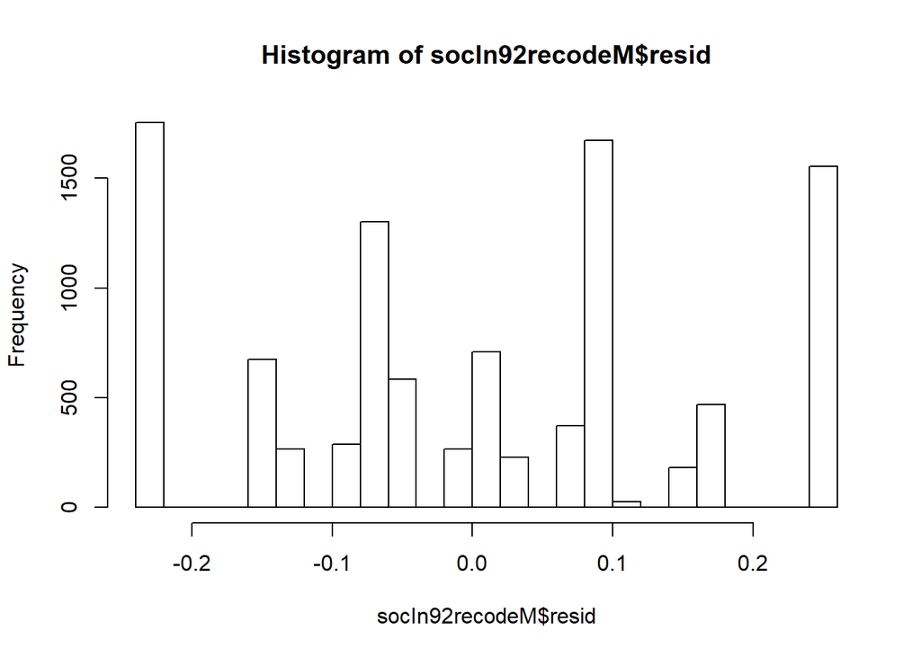

```r
# They do not follow a normal distribution

hist(socIn92recodeM$resid, breaks = 20)
```